# Refresher from Previous Coursework

Lecture 1B

PUBHBIO 6250

## Types of (Quantitative) Data

The type of **summary statistics** to calculate depends on the data type:

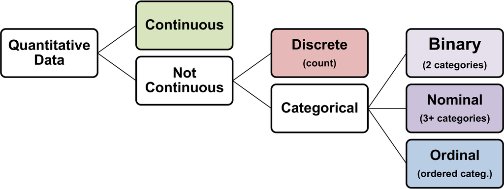

## Summary Statistics for Different Data Types

| Data Type | Commonly Computed Summary Statistics |
| --- | --- |
| Continuous | mean and standard deviation median and interquartile range |
| Discrete | mean and standard deviation median and interquartile range |
| Binary | proportion |
| Nominal | proportion |
| Ordinal | proportion |

## Types of (Quantitative) Data

The type of **regression model** to use depends on the **outcome variable’s** data type – with a bit more nuance:

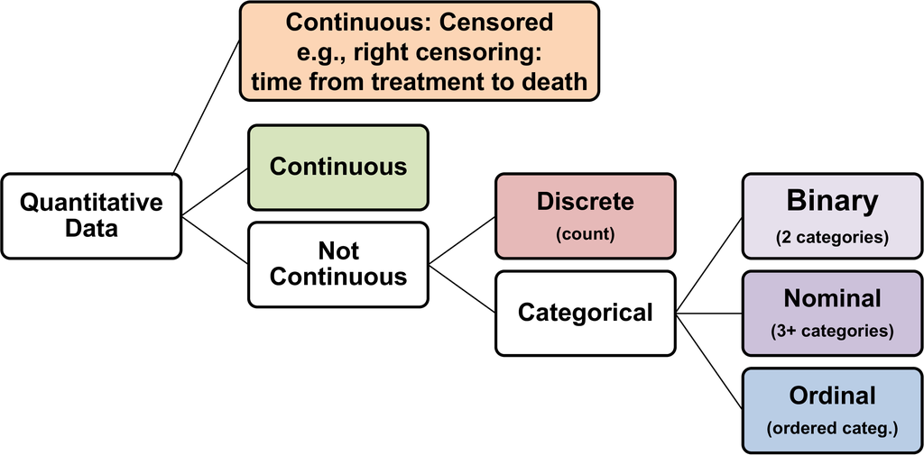

## Preview of Regression Methods to Come

Regression methods in this course (and the prerequisite courses):

| Method | Dependent variables ($\mathbf{Y}$) |
| --- | --- |
| Linear regression | Continuous |
| Logistic regression | Binary (yes/no; 1/0) |
| Cox proportional hazards regression | Survival time/time to event (censored) |
| Poisson regression | Count (number of events) |

We will learn about these methods in the context of data that can be considered a **simple random sample** from the population of interest.

Then we will consider what happens when we have data collected from a **complex survey sampling design**.

## Illustrative Setting

- Suppose we are interested in investigating the **health of older adults in the U.S.**
- We have access to a random sample of adults who receive Medicare ($n=200$)
- Lots of measurements and questionnaire data

Let’s review some example **research questions** that you know how to answer with **statistical tools already in your toolbox**…

…and some for which we’ll need **new statistical tools**.

## Research Question #1

**Is serum cholesterol associated with fibrinogen?**

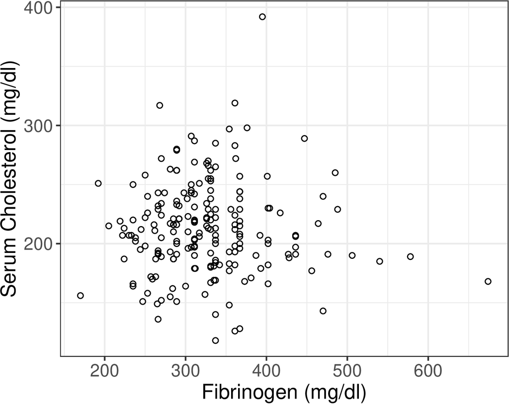

**Statistical tool:** Linear regression

- $Y$ = cholesterol (mg/dl)
- $X$ = fibrinogen (mg/dl)
- Parameter of interest: slope, $\beta_1$ in regression model: $E[Y|X] = \beta_0 + \beta_1 X$

Results: $\hat{\beta}_1 = -0.0063$, 95% CI = $(-0.086, 0.073)$, $p$-value = $0.87$

*Can also answer this question using Pearson correlation.* $\hat{r} = -0.01$, 95% CI = $(-0.15, 0.13)$, $p$-value = $0.87$.

## Research Question #1 – Extensions

**RQ1a:** **Is serum cholesterol associated with fibrinogen, controlling for age (a potential confounder)?**

- **Statistical tool:** Multiple linear regression
  - $Y$ = cholesterol, $X$s = fibrinogen, age
  - Regression model: $E[Y|X] = \beta_0 + \beta_1 FIB + \beta_2 AGE$
  - Parameter of interest: **$\beta_1$**

**RQ1b:** **Does the relationship between cholesterol and fibrinogen differ by (binary) sex?**

- **Statistical tool:** Multiple linear regression
  - $Y$ = cholesterol, $X$s = fibrinogen, sex, fibrinogen$\times$sex (interaction!)
  - Regression model: $E[Y|X] = \beta_0 + \beta_1 FIB + \beta_2 MALE + \beta_3 FIB \times MALE$
  - Parameter of interest: **$\beta_3$**
  - Slope: $\beta_1$ for females and $\beta_1 + \beta_3$ for males

## Research Question #2

**Is serum cholesterol associated with smoking status (smoker, non-smoker)?**

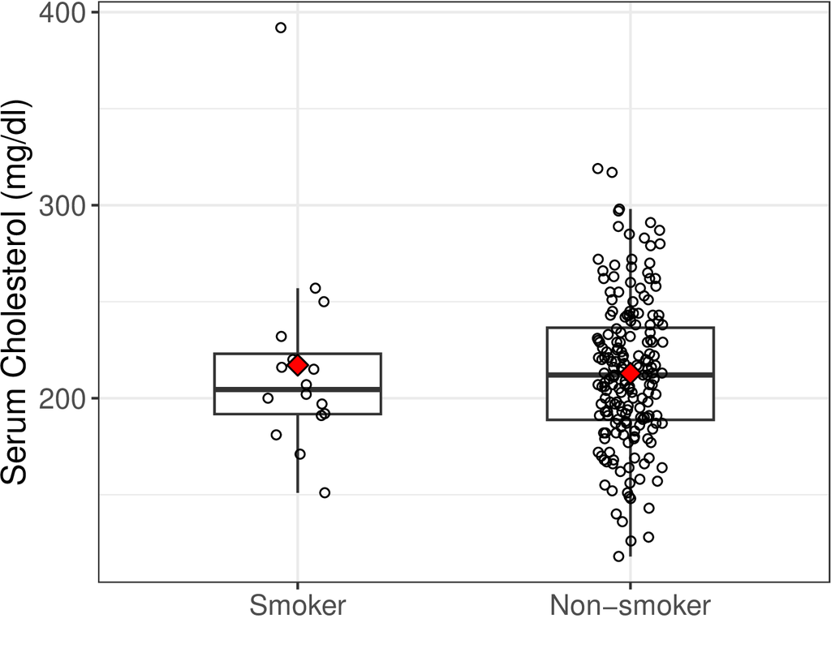

**Statistical tool:** Two-sample t-test

- $Y$ = cholesterol
- Grouping variable $X$ = smoking status
- Parameter(s) of interest: Group means (and their difference)
- $H_0: \mu_{smoke} = \mu_{nonsmoke}$

Results: $\bar{y}_{smoke}= 217.1$, $\bar{y}_{nonsmoke}= 212.9$, $p$-value = $0.68$

*Can also answer this question using linear regression,* $E(Y|X) = \beta_0 + \beta_1 X$.

## Research Question #2 – Extension

**RQ2a:** **Is serum cholesterol associated with smoking status, controlling for alcohol consumption (a potential confounder)?**

- **Statistical tool:** Multiple linear regression
  - $Y$ = cholesterol
  - $X$s = smoking status, alcohol consumption
  - Regression model: $E[Y|X] = \beta_0 + \beta_1 SMOKE + \beta_2 ALCOHOL$
  - Parameter of interest: **$\beta_1$**

## Research Question #3

**Are smokers more likely to have high CRP than non-smokers?**

|  | High CRP |
| --- | --- |
| Smokers | 7/16 (44%) |
| Non-Smokers | 85/184 (46%) |

**Statistical tool:** Chi-squared test

- $Y$ = CRP status (binary: high/not high)
- $X$ = smoking status (binary)
- Parameter(s) of interest: Proportion with high CRP in each smoking group
- $H_0: p_{smokers} = p_{nonsmokers}$

Results: $\hat{p}_{smokers}= 0.44$, $\hat{p}_{nonsmokers}= 0.46$, $p$-value = $0.85$

*Can also answer this question using logistic regression.*

## Research Question #3 – Extension

**RQ3a:** **Is there an association between smoking status and high CRP, controlling for alcohol consumption (a potential confounder)?**

- **NEW Statistical tool:** (Multiple) logistic regression
  - $Y$ = CRP status (binary)
  - $X$s = smoking status, alcohol consumption
  - Regression model: $\text{logit}(\Pr(Y=1))= \beta_0 + \beta_1 SMOKE + \beta_2 ALCOHOL$
  - Regression technique that models the odds of a binary outcome as a function of *multiple* covariates (categorical, continuous)
  - Good news: interpretation of $\beta$s is the same $\rightarrow e^\beta$ = odds ratio!

## Research Question #4

**Is having high CRP associated with earlier death?**

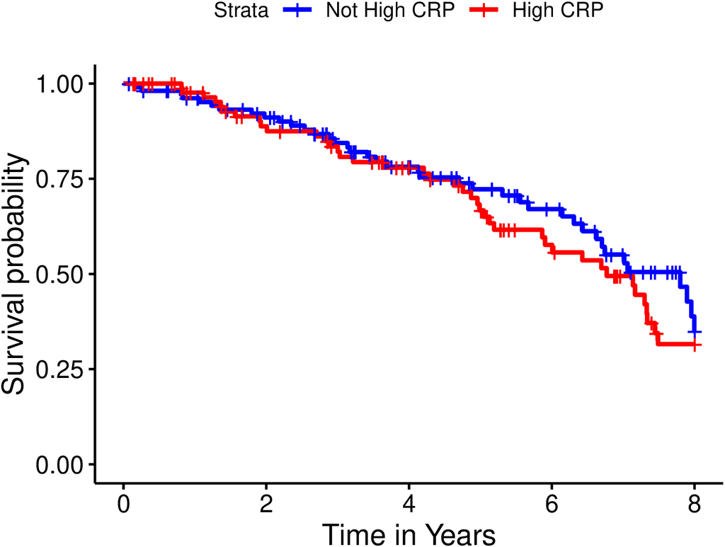

**Statistical tools:** Kaplan-Meier curves; logrank test

- $Y$ = time to death (censored – not all people dead at study end)
- $X$ = CRP status (binary: high/not high)
- Parameter(s) of interest: median survival time in each CRP group
- $H_0: S_1(t) = S_2(t)$ (logrank test)

Results: Median survival: High CRP = $6.8$ yrs, Not High = $7.8$ yrs, $p$-value = $0.41$

## Research Question #4 – Extension

**RQ4a:** **Is having high CRP associated with earlier death, controlling for sex and triglyceride level (potential confounders)?**

- **NEW Statistical tool:** Cox proportional hazards regression
  - $Y$ = time to death (censored)
  - $X$s = CRP status, sex, triglyceride level
  - New (to you) regression technique that models the relative hazard of death (“instantaneous risk of death”) as a function of covariates (categorical, continuous)
  - Note: Does not have to be **death** – could be time to another type of event (recurrence, recovery, relapse, etc.)

## Research Question #5

**Do older adults tend to have more urgent care visits?**

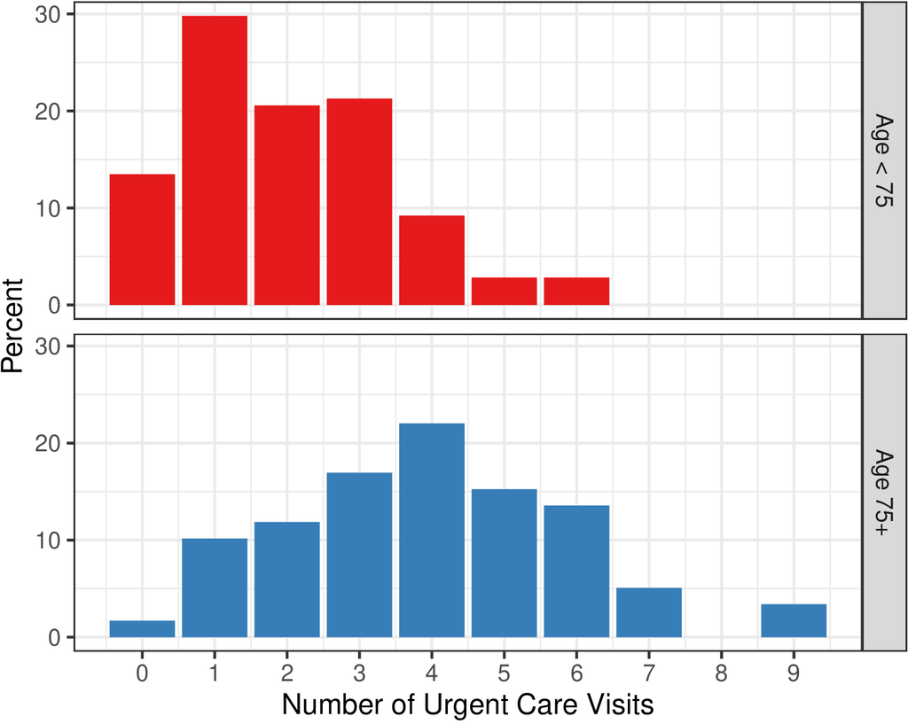

**NEW Statistical tool:** Poisson regression

- $Y$ = number of urgent care visits
- $X$ = age
- New (to you) regression technique that models the frequency of events as a function of covariates (categorical, continuous)
- Allows for **different lengths of follow-up** (e.g., some adults followed for 12 months, some for 18 months, etc.)

## Similarities Across Regression Techniques

We will do a lot of similar things across the different types of regression models:

- Interpreting coefficients ($\beta$s) – sometimes requiring transformation (e.g., $e^\beta$)
- Conducting hypothesis tests about regression coefficients
- Controlling for/adjusting for covariates (e.g., potential confounders)
- Using **interaction terms** to investigate whether the effect of one variable on the outcome depends on the level of another variable
- Assessing model fit
- Using software to obtain estimates!